# Home Assignment 1

### Youssef Benhachem

**1.**

**The input space**: $X$ = {$X_i, i \in [1,n]$ } $dim(X)=28\times28$

**The output space**: $Y$ = {-1, 1} $dim(Y)=1$

**2.**

**(a)-** Empirical risk associated with the 0-1 loss : $\hat{R}(\theta) = \frac{1}{n}\sum_{i=1}^{n}1_{f_\theta(x_i)\neq y_i}$

True risk associated with the 0-1 loss : $R(\theta) = E(1_{f_\theta(X)\neq Y})$

In this case, the empirical risk is complicated to minimize because it is not differentiable, and hence we cannot use the classical iterative approaches like gradient descient, neither can we easily find a normal solution (if it exists)

**(b)-** Test data should be used to assess performance, that's because it is **new** data for the model, and hence it will give us an expectation of how the model would behave on data he wasn't trained on

**(c)-** The optimization problem associated with :

- Linear Least Square Regression: $$ min_{\theta} \frac{1}{n} \sum_{i=1}^{n}(f_\theta(x_i)-y_i)^2$$

  where $f_\theta(x_i) = \theta^Tx_i$
- Linear Logistic Regression: $$ min_{\theta} \frac{1}{n} \sum_{i=1}^{n} log(1 + e^{-y_i \;f_\theta(x_i)} )$$

  where $f_\theta(x_i) =\theta^Tx_i$

**Note** : In the models above, we have added a *fake feature* to our observations $x_i$,as follow : $$\forall i \in [1,n] \;\ x_i^{(0)} = 1$$

**(d)-** Under the logistic model : $$ P(Y=1|X) = \frac{1}{1+e^{-\theta^TX}}$$

**(e)-** *Link between logistic regression and maximum likelihood estimation:*

We know that under the logistic model :

$\forall i \in [1,n]$

- $ p(y_i = 1|x_i ; \theta) =\frac{1}{1+e^{-\theta^TX}} = \sigma ( \theta^Tx_i) $
- $ p(y_i = -1|x_i ; \theta) = \frac{1}{1+e^{\theta^TX}} = \sigma (- \theta^Tx_i)$

Which is equivalent to : $\forall i \in [1,n]$ $ p(y_i|x_i ; \theta) = \sigma(y_i \theta^Tx_i) $

The Likelihood function's expression is : $$L(\theta) = \prod_{i=1}^{n} p(y_i|x_i;\theta) = \prod_{i=1}^{n}\frac{1}{1+e^{-y_i\theta^TX}} $$

Which gives us the loglikelihood expression : $$ log(L(\theta)) = -\sum_{i=1}^{n} log(1+e^{-y_i\theta^TX})$$

Then : $$argmax_\theta \; logL(\theta) = argmin_\theta \hat{R}(\theta)$$

We have therefore derived the expression of the *Logistic Loss* from the **MLE**(maximum likelihood estimator)

*Practical reasons behind the use of log likelihood function*

- The likelihood function is expressed at the product of functions,however the product of functions is hard to differentiate, and that's why we use the log likelihood as it is expressed as the sum of functions.
- Since the $log(x)$ is a monotonically increasing function, we have $argmax_\theta log(L(\theta)) = argmax_\theta(L(\theta))$
- We also notice, that the use of log likelihood function gave us a probabilistic interpretation of the Logistic Loss (Binary Cross Entropy)

**(3)-** As the degree of our polynomials increases, the *training error* and the *bias* will go *down*, however the *test error* and the *variance* will go up. This is illustrated by the figure below:

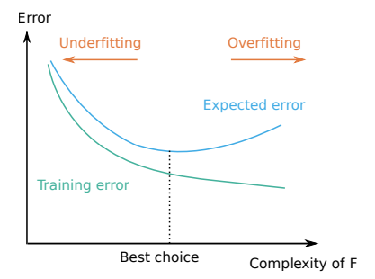

**(4)-** SGD rule for:

```
(a)- Linear least-squares regression
```

$$\forall k \in [0,d] \; \theta_k \leftarrow \theta_k - 2\eta (f_\theta(x_i) - y_i)x_i^{(k)}$$

```
where
```

$$f_\theta(x_i) = \theta^Tx_i$$

```
(b)- Logistic regression
```

$$\forall k \in [0,d] \; \theta_k \leftarrow \theta_k + \eta \;(y_i \; \sigma (-y_i\;f_\theta(x_i)))x_i^{(k)}$$

```
where
```

$$\sigma(-y_i\;f_\theta(x_i)) = \frac{1}{1+e^{y_i\;f_\theta(x_i)}}$$

```
(c)- The perceptron learning algorithm
```

$$\forall k \in [0,d] \; \theta_k \leftarrow \theta_k - \eta (g(f_\theta(x_i)) - y_i)x_i^{(k)}$$

```
where
```

$$g(f_\theta(x_i)) = 1 \;\;if\;\; \theta^Tx_i \geq 0 \;\;and \:\:0\;\; if\;\; \theta^Tx_i < 0$$

**(5)- a**

### Logistic Regresion

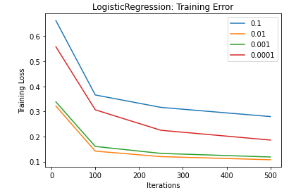

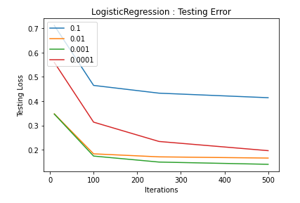

=> The best learning rate is then for Logistic Regression is then $0.001$ followed by $0.01$

### Linear Least Square Regression

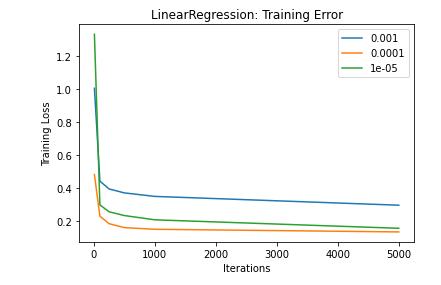

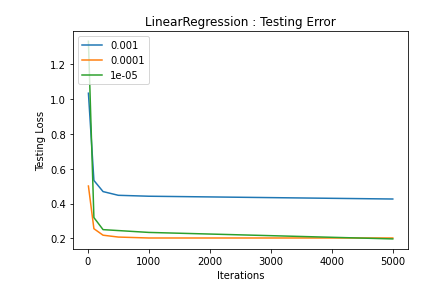

=> The best learning rate is then for OLS is then $0.0001$ followed by $10^{-5}$

### Perceptron

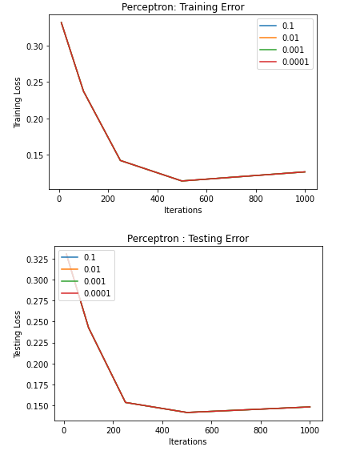

=> We see that the loss of the *Perceptron* does **not depend** on the learning rate, given that all the curves are *overlapped*, which is due to the use of the sign function in the predict function of the *Perceptron*

### (5)-b Images of the estimators for the three models

### Legend :

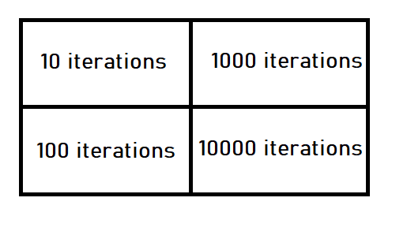

### Logistic Regresion

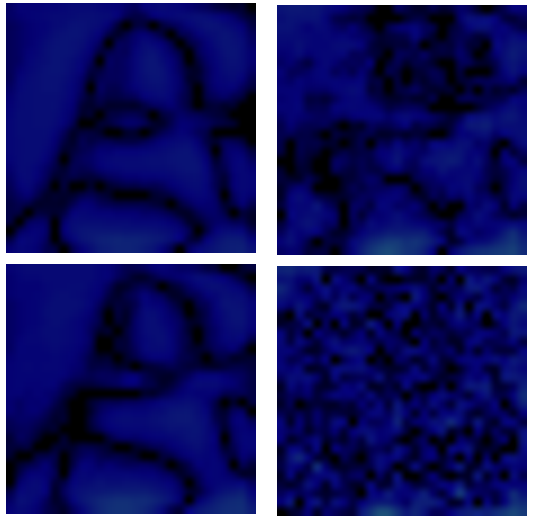

### Linear Least Square Regression (OLS)

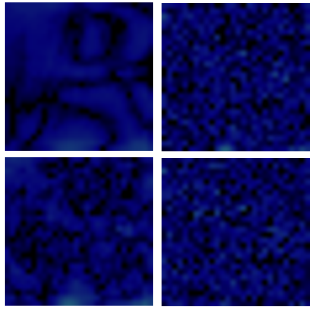

### Perceptron

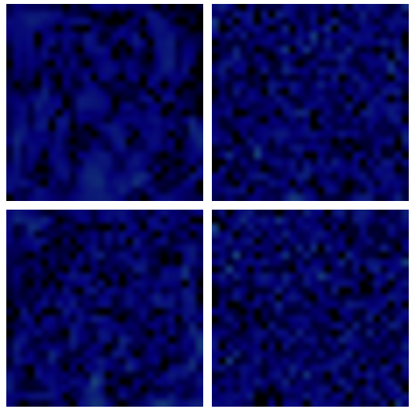

### Comment:

After 10 iterations, a pattern appears Logistic Regression and OLS. However as our model learns, the images of the estimaros tend to be random.

### (6) - K Nearest Neighbors (KNN)

**(a)** - *Definition n of the k-nearest neighbors classification rule with $l2$ metric*

In contrary to Linear Regression, Logistic Regression and the Pereptron, which are based on **Risk Minimization**, KNN is a method based on **local averaging**. In fact, for a new input $x \in R^d$, the algorithm looks at the $k$ nearest points $x_i$ in the data set, and uses a *majority vote* among them

**(b)** -

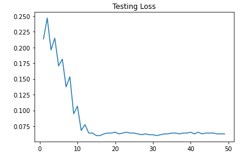

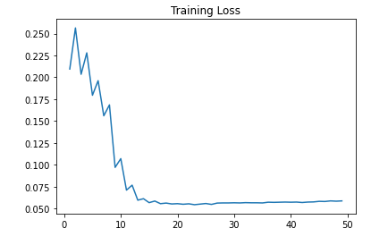

### (7)- MLP

The number of paramters needed to train the *MLP* is **25219** parameters where **24400** are weights and **819** biases

### (8)- Results of the models:

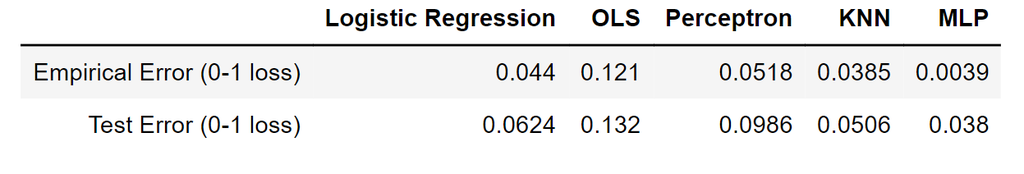

### Comment on the results :

- The best algorithm for our classification problem is **MLP** with a test error of **0.038**, which is expected thanks to its ability to model non-linear relationships, which is not the case for **GLMs** (General Linear Models) like **Logistic Regression, Linear Regression** and the **Perceptron Algorithm**.
- The least performing algorithm is **OLS**, with a test error of **0.132**, which was expected since Linear Regression was designed for regression problems, and not classification ones, and is easily affected by noise, in other words, in classification problems, Linear Regression is easily prone to overfitting

### (9)- Why is it important to regularize ?

**Regularization** takes into account the trade-off between *Learning* and *Overfitting*, in other words, it founds the right balancing between the *bias* and the *variance* of a model. Regularization thus, discourages learning a complex model in order to avoid overfitting.

### (9.a)- SGD rule for the three models using $l2$ regularization ?

### Logistic Regression

$$ \forall k \in [0, d] \;\; \theta_{k+1} \leftarrow (1-2 \lambda \eta)\theta_k+ \eta \;(y_i \; \sigma (-y_i\;f_\theta(x_i)))x_i^{(k)}$$

$$ where \;\; f_\theta(x) = \theta^Tx$$

### Linear Least Squares Regression

$$ \forall k \in [0, d] \;\; \theta_{k+1} \leftarrow (1-2 \lambda \eta)\theta_k- 2 \eta(f_\theta(x) -y)x^{(k)}$$

$$ where \;\; f_\theta(x) = \theta^T x$$

### Perceptron

$$ \forall k \in [0, d] \;\; \theta_{k+1} \leftarrow (1-2 \lambda \eta)\theta_k- \eta(f_\theta(x) -y)x^{(k)}$$

$$where f_\theta(x) = 1 \;\;if\;\; \theta^Tx \geq 0 \;\;and \:\:0\;\; if\;\; \theta^Tx < 0$$

### (9.b)- SGD Updates for the three models using $l1$ regularization ?

### Logistic Regression

$$ \forall k \in [0, d] \;\; \theta_{k+1} \leftarrow \theta_k - \eta \lambda sgn(\theta_k) + \eta y \sigma(-y\theta^Tx) x_k$$

$$ where \;\; \sigma(x) = \frac{1}{1+e^{-x}}$$

### Linear Least Squares Regression

$$ \forall k \in [0, d] \;\; \theta_{k+1} \leftarrow \theta_k - \eta \lambda sgn(\theta_k) - 2 \eta(f_\theta(x) -y)x^{(k)}$$

$$ where \;\; f_\theta(x) = \theta^T x$$

### Perceptron

$$ \forall k \in [0, d] \;\; \theta_{k+1} \leftarrow \theta_k - \eta \lambda sgn(\theta_k) - \eta(f_\theta(x) -y)x^{(k)}$$

$$where f_\theta(x) = 1 \;\;if\;\; \theta^Tx \geq 0 \;\;and \:\:0\;\; if\;\; \theta^Tx < 0$$

### (10-) Regularization of logistic regression

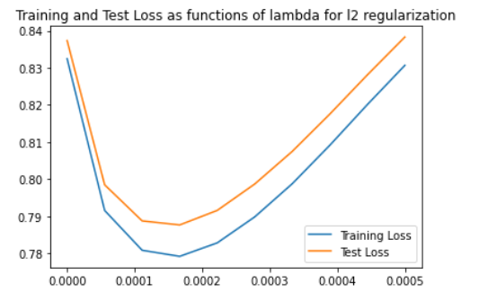

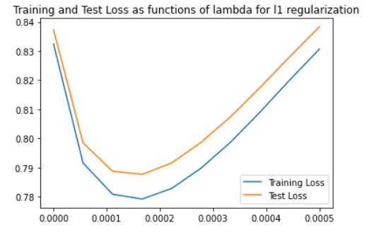

#### (b)- Best value for $\lambda$

=> From the plots above, we deduce that the best value for lambda for the $l2$ norm, is arround $0.00016$

=> From the plots above, we deduce that the best value for lambda for the $l1$ norm, is arround $0.00016$

#### Tuning the parameter $\lambda$ :

- To tune the paramter $\lambda$, we can -like done above- use **multistep greed search** to find the optimal $\lambda$, which means the one that minimizes the **testing logistic loss**.
- Another method would be to calibrate $\lambda$ using cross validation, like we have done for $K$ in the KNN algorithm

#### (c)- Images of the estimator $\hat{\theta}_\lambda$

#### Images of the estimator $\hat{\theta}_\lambda$ for the $l2$ norm

#### Legend for the images below

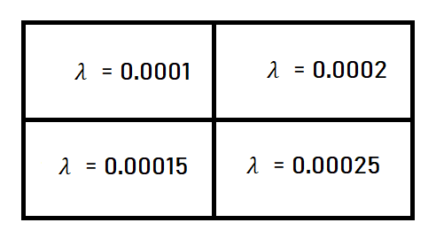

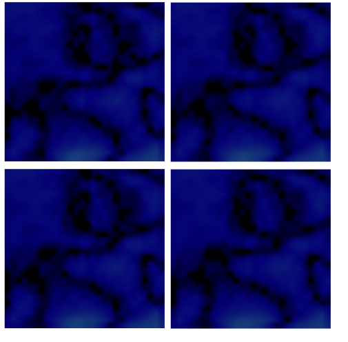

#### Images of the estimator $\hat{\theta}_\lambda$ for the $l1$ norm

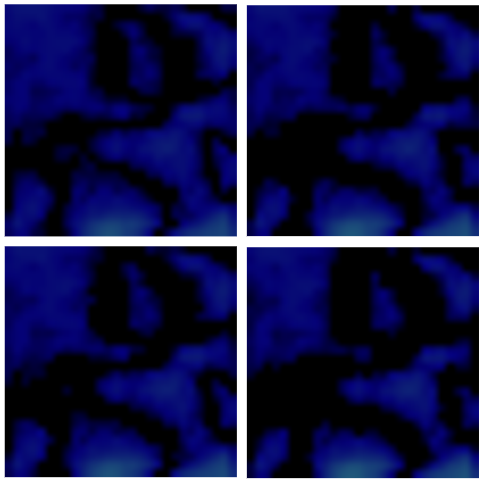